# Exercise Solution Sheet

Okan Sarioglu Leon Siefken

2023-08-21

#Chapter E: Solution Exercises

## Exercises Chapter 1:

### Exercise 1: Create a vector called `my_vector` with the values 1,2,3 and check is class.

```r
my_vector <- c(1,2,3)

class(my_vector)
```

### Exercise 2: Create a Matrix called `student`. This should contain information about the `name`, `age` and `major`. Make three vectors and bind them together to a the matrix `student`. Print the matrix.

```r
name <- c("Sören", "Fatma", "Klaus", "Fidelius", "Sven")
age  <- c(18, 22, 21, 19, 28)
major <- c("Political Science", "Law", "Buisness Administration",
           "Philosophy", "Law")

student <- cbind(name,
                 age,
                 major)

print(student)
```

### Exercise 3: Write an if-else statement that checks if a given number is positive or negative. If the number is positive, print “Number is positive”, otherwise print “Number is negative”. Feel free to decide if you want to use the ifelse function or the ifelse condition.

```r
#ifelse() function

number <- -4

ifelse(number > 0, "Positive Number", "Negative Number")

#ifelse condition

if (number > 0) {
  print("Positive Number")
} else {
  print("Negative Number")
}
```

### Exercise 4: Write an if-else ladder that categorizes a student’s grade based on their score. The grading criteria are as follows:

Score >= 90: “A” Score >= 80 and < 90: “B” Score >= 70 and < 80: “C” Score >= 60 and < 70: “D” Score < 60: “F”

```r
#ifelse() function

score <- 78

ifelse(score >= 90, "A",
       ifelse (score >= 80 & score < 90, "B",
               ifelse(score >= 70 & score < 80, "C",
                      ifelse(score >= 60 & score < 70, "D",
                             ifelse(Score < 60, "F")))))

#ifelse condition

if (score >= 90) {
  print("A")
} else if (score >= 80 & score < 90) {
  print("B")
} else if (score >= 70 & score < 80) {
  print("C")
} else if (score >= 60 & score < 70) {
  print("D")
} else if (score < 60) {
  print("F")
}
```

## Exercise Chapter 2:

### Exercise 1: You are interested in discrimination and the perception of the judicative. More specifically, you want to know if people, who fell discriminated evaluate courts differently. Below you see a table with all variables you want to include in your analysis:

[output not shown]

1. Wrangle the data, and assign it to an object called **ess**.
2. Select the variables you need
3. Filter for Austria, Belgium, Denmark, Georgia, Iceland and the Russian Federation
4. Have a look at the codebook and code all irrelevant values as missing. If you have binary variables recode them from 1, 2 to 0 to 1
5. You want to build an extremism variable: You do so by subtracting 5 from the from the variable and squaring it afterwards. Call it extremism
6. Rename the variables to more intuitive names, don’t forget to name binary varaibles after the category which is on 1
7. drop all missing values
8. Check out your new dataset

```r
ess <- d1 %>%
  select(cntry, dscrgrp, cttresa, agea, gndr, eisced, lrscale) %>% #a
  filter(cntry %in% c("AT", "BE", "DK", "GE", "IS","RU")) %>% #b
  mutate(dscrgrp = case_when( #c
    dscrgrp == 1 ~ 0,
    dscrgrp == 2 ~ 1,
    dscrgrp %in% c(7, 8, 9) ~ NA_real_,
    TRUE ~ dscrgrp),
    cttresa = case_when(
    cttresa %in% c(77, 88, 99) ~ NA_real_,
    TRUE ~ cttresa),
    agea = case_when(
    agea == 999 ~ NA_real_,
    TRUE ~ agea),
    gndr = case_when(
      gndr == 1 ~ 0,
      gndr == 2 ~ 1,
      gndr == 9 ~ NA_real_
    ),
    eisced = case_when(
      eisced %in% c(55, 77, 88, 99) ~ NA_real_,
      TRUE ~ eisced),
    lrscale = case_when(
      lrscale %in% c(77, 88, 99) ~ NA_real_,
      TRUE ~ lrscale),
    extremism = (lrscale - 5)^2 #d, you could do this step also in a separate mutate function if you think that is more intuitive
  ) %>%
  rename(discriminated = dscrgrp,
         court = cttresa,
         age = agea,
         female = gndr,
         education = eisced,
         lrscale = lrscale,
         extremism = extremism
         ) %>%
  drop_na()

#Checking the dataset

head(ess)
```

### Exercise 2: Merging Datasets

The `gapminder` package in R loads automatically the gapminder dataset. gapminder is an independent educational non-profit fighting global misconceptions, check out their website: https://www.gapminder.org/ The gapminder dataset is already loaded.

1. Get an overview of the gapminder dataset. There are different ways to do so, you can choose by yourself

```r
head(gapminder)#my favourite

glimpse(gapminder) #dplyr function

skimr::skim_without_charts(gapminder) #some descriptives
```

2. We already loaded World Bank Data in the object **wb**. Merge the two datasets! Use `left_join()` and merge the gapminder dataset into the World Bank data. Define a new object called mer_df

```r
head(wb)

#With pipeline

mer_df <- wb %>%
  left_join(gapminder, by = c(
            "country" = "country",
            "year" = "year"))

#without pipeline

# mer_df <- left_join(wb, gapminder, by = c("country" = "country", "year" = "year")
```

## Exercises Chapter 3:

### Exercise 1: Power to the People

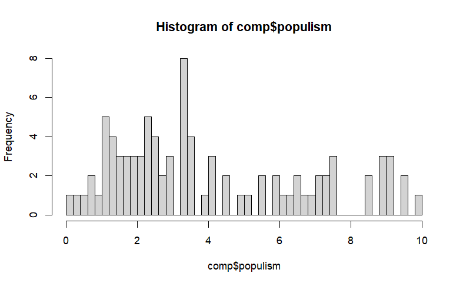

### Exercise 2: Anti-Immigration Sentiment, That’s what `the People` want…?

```r
cor(comp$generalwill, comp$immigration, method = "kendall", use = "complete.obs")
```

```
[1] -0.5139008
```

## Exercise Chapter 4:

[figure not shown]

## Exercises Chapter 5:

## Exercise Section

### Exercise 1: Write a `for` loop that prints the square of each number from 1 to 10

```r
#Assigning an object for a better workflow
number <- 10

#The Loop
for (i in 1:number) {
  sq <- i^2
  print(sq)
}
```

### Exercise 2: Do the same, but this time defining a function that squares numbers.

```r
#Defining a function for squaring

sq <- function (x) {

  result <- x^2
  print(result)

}

#Defining a vector containing a vector from 1 to 10
numbers <- c(1:10)

#Applying the number
sq(numbers)
```

### Exercise 3: This is the midnight formula separated in two equations:

**Hint**: You need two split up the formula into two equations with two outputs.

```r
mnf <- function (a,b,c) {

  x_1 <- (-b + sqrt(b^2 - 4*a*c))/(2*a)

  print(x_1)

  x_2 <- (-b - sqrt(b^2 - 4*a*c))/(2*a)

  print(x_2)
}


mnf(2, 6, 8)
```

### Exercise 4: Zodiac Fortune Teller

In the last exercise of this course, we will learn about our future based on our Zodiac Sign. For this we well need a `function`, a `loop` and an `ifelse` condition or function.

```r
fortune <- function(sign) {

  #Fortunes vector
  fortunes <- c("Exciting opportunities are on the horizon for you!",
              "Your creative talents will shine brightly this month!",
              "Financial abundance is heading your way!",
              "You will experience a period of personal growth and
              self-discovery!",
              "New friendships will bring joy and fulfillment into you
              life!",
              "Your hard work and dedication will pay off in unexpected
              ways!",
              "Travel plans will bring you exciting adventures and memorable
              experiences!",
              "A long-awaited dream will finally become a reality!",
              "Your positive attitude and optimism will attract great
              success!",
              "Love and romance will blossom in your life!",
              "Embrace change and seize new opportunities with confidence!",
              "Your intuitive insights will guide you to make wise
              decisions!",
              "A new career opportunity will open doors to success and
              fulfillment!",
              "You have the power to overcome any challenges that come your
              way!",
              "Your generosity and kindness will be rewarded abundantly!",
              "Self-care and self-love will lead to inner peace and harmony!"
              )

  #Zodiac signs vector
  zodiac_signs <- c("Aries", "Taurus", "Gemini", "Cancer", "Leo", "Virgo",
                    "Libra", "Scorpio", "Sagittarius", "Capricorn",
                    "Aquarius", "Pisces")
  #For loop
  for (i in 1:length(zodiac_signs)) {
    if (sign == zodiac_signs[i]) {
      return(fortunes[i])
    }
  }
}

#Let us see our fortune

fortune("Aries") #Do not forget to put your sign in quotation marks
```